# soccR

Anatole GAYANT, Jules AVIGNON, Clément PEREON

2023-04-28

SoccR

oui, parce que ça fait un petit jeu de mot avec R et soccer

Analyse des matchs de la Ligue des champions 2020-2021

Anatole GAYANT, Jules AVIGNON, Clément PEREON

Date de remise : 11/05/2023

Pour notre projet de R avancé, nous avons choisi de récupérer les données de tous les matchs de l’édition 2020-2021 de la Ligue des champions à partir de l’API football-data.org. Pour cela, nous avons utilisé les librairies httr et jsonlite.

Nous avons d’abord envoyé une requête GET à l’API en spécifiant l’URL et le token d’authentification dans les en-têtes de la requête. Nous avons ensuite converti la réponse en texte brut et l’avons parseé en utilisant la fonction fromJSON de jsonlite.

Finalement, on extrait les données des matchs en accédant à l’élément “matches” du JSON renvoyé par l’API.

Voici le code utilisé pour récupérer les données :

```r
library(httr)
library(jsonlite)

#Récupération des données de tous les matchs de la Champions League
url <- "https://api.football-data.org/v4/competitions/CL/matches?season=2020"
response <- GET(url, add_headers("X-Auth-Token" = "d0d8b5553bd34025bac768b663973df2"))
data <- fromJSON(rawToChar(response$content))
matches <- data$matches
```

# Liste des matchs

On récupère les données de tous les matchs de la Ligue des Champions 2020-2021 depuis une API, et les stocke dans un objet “matches”. Ensuite, le code utilise les packages “dplyr”, “DT” et “ggplot2” pour transformer ces données en un tableau affichant les scores des matchs avec les noms des équipes, les dates, et triés par ordre chronologique décroissant. Enfin, la fonction “datatable” de DT est utilisée pour afficher ce tableau dans le R Markdown, avec des options pour la pagination, la recherche et le renommage des colonnes.

```r
library(dplyr)
library(DT)
```

```r
library(ggplot2)
matches_tbl <- as_tibble(matches)

matches_scores <-
  select(matches_tbl, homeTeam, awayTeam, score, utcDate) |>
  mutate(
    homeTeam_name = pull(homeTeam, "name"),
    awayTeam_name = pull(awayTeam, "name"),
    home_score = pull(score$fullTime, "home"),
    away_score = pull(score$fullTime, "away"),
    total_score = paste(home_score, "-", away_score),
    date = as.Date(utcDate))|>
  select(homeTeam_name,
         awayTeam_name,
         total_score,
         date) |>
  arrange(desc(matches_tbl$utcDate))

datatable(matches_scores, options = list(pageLength = 10, lengthMenu = c(10, 20, 50)),
          filter = "top", rownames = FALSE,
          colnames = c("Home Team", "Away Team", "Total Score", "Date"),
          caption = "Tableau des scores Champions League 2021")
```

| Home Team | Away Team | Total Score | Date |
| --- | --- | --- | --- |
| Manchester City FC | Chelsea FC | 0 - 1 | 2021-05-29 |
| Chelsea FC | Real Madrid CF | 2 - 0 | 2021-05-05 |
| Manchester City FC | Paris Saint-Germain FC | 2 - 0 | 2021-05-04 |
| Paris Saint-Germain FC | Manchester City FC | 1 - 2 | 2021-04-28 |
| Real Madrid CF | Chelsea FC | 1 - 1 | 2021-04-27 |
| Borussia Dortmund | Manchester City FC | 1 - 2 | 2021-04-14 |
| Liverpool FC | Real Madrid CF | 0 - 0 | 2021-04-14 |
| Chelsea FC | FC Porto | 0 - 1 | 2021-04-13 |
| Paris Saint-Germain FC | FC Bayern MÃ¼nchen | 0 - 1 | 2021-04-13 |
| FC Porto | Chelsea FC | 0 - 2 | 2021-04-07 |

[output cut: 168 more lines]

# Association du tour

```r
matches_scores$tour[1] <- "finale"
matches_scores$tour[2:5] <- "demis"
matches_scores$tour[6:13] <- "quarts"
matches_scores$tour[14:29] <- "huitiemes"
matches_scores$tour[30:nrow(matches_scores)] <- NA
matches_scores <-  na.omit(matches_scores)
```

# Représentation graphique

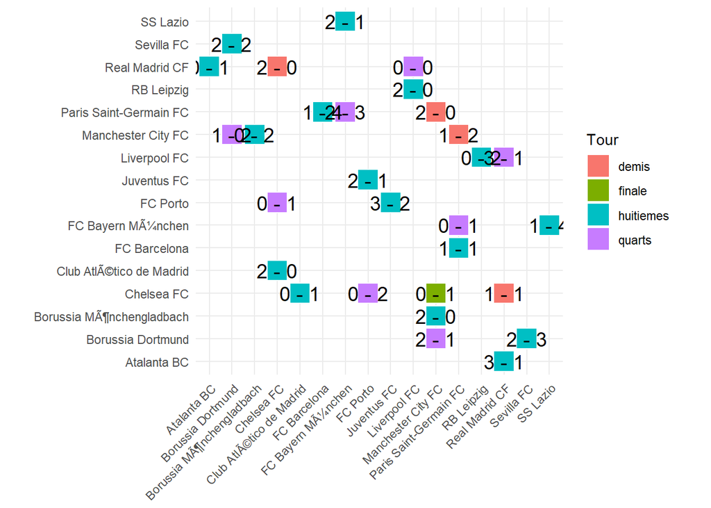

```r
# Transformation du format des scores

matches_scores$home_score <- as.numeric(sub("^([0-9]+) - ([0-9]+)$", "\\1", matches_scores$total_score))
matches_scores$away_score <- as.numeric(sub("^([0-9]+) - ([0-9]+)$", "\\2", matches_scores$total_score))

# Création de la variable 'winner'
matches_scores$winner <- with(matches_scores, ifelse(home_score > away_score, homeTeam_name, ifelse(home_score < away_score, awayTeam_name, "Draw")))

# Création du graphique avec ggplot2
ggplot(matches_scores, aes(x = homeTeam_name, y = awayTeam_name, fill = tour)) +
  geom_tile(aes(width = 0.9, height = 0.9), color = "white", size = 0.5) +
  geom_text(aes(label = total_score), size = 5) +
  scale_fill_discrete(name = "Tour") +
  theme_minimal() +
  labs(x = NULL, y = NULL) +
  coord_fixed() +
  theme(axis.text.x = element_text(angle = 45, hjust=1))
```

Nous nous intéressons maintenant à la page wikipédia de l’édition 2020-2021 de la Ligue des champions : https://fr.wikipedia.org/wiki/Ligue_des_champions_de_l%27UEFA_2020-2021

```r
library(rvest)
url <- "https://fr.wikipedia.org/wiki/Ligue_des_champions_de_l%27UEFA_2020-2021"
data_html <- read_html(url)
```

```r
# Tableau des équipes qualifiées à l'issue de la phase de groupe
css_selector <- "#mw-content-text > div > table:nth-of-type(25)"
df_qualifies <- data_html |> html_nodes(css_selector) |> html_table()
names(df_qualifies[[1]])[2] <- "premiers"
names(df_qualifies[[1]])[3] <- "deuxiemes"
datatable(df_qualifies[[1]])
```

|  | Groupe | premiers | deuxiemes |
| --- | --- | --- | --- |
| 1 | A | Bayern Munich | Atlético de Madrid |
| 2 | B | Real Madrid | Borussia Mönchengladbach |
| 3 | C | Manchester City | FC Porto |
| 4 | D | Liverpool FC | Atalanta Bergame |
| 5 | E | Chelsea FC | Séville FC |
| 6 | F | Borussia Dortmund | SS Lazio |
| 7 | G | Juventus FC | FC Barcelone |
| 8 | H | Paris Saint-Germain | RB Leipzig |

Voici le détail de la phase à élimination directe avec, pour chaque tour, les scores aux matchs allers, aux matchs retours et totaux.

## Huitièmes de finale

```r
css_selector <- "#mw-content-text > div > table:nth-of-type(26)"
df_huit <- data_html |> html_nodes(css_selector) |> html_table()
datatable(df_huit[[1]])
```

|  | Équipe | Aller | Total | Retour | Équipe |
| --- | --- | --- | --- | --- | --- |
| 1 | Borussia Mönchengladbach | 0 – 2 | 0 – 4 | 0 – 2 | Manchester City |
| 2 | SS Lazio | 1 – 4 | 2 – 6 | 1 – 2 | Bayern Munich |
| 3 | Atlético de Madrid | 0 – 1 | 0 – 3 | 0 – 2 | Chelsea FC |
| 4 | RB Leipzig | 0 – 2 | 0 – 4 | 0 – 2 | Liverpool FC |
| 5 | FC Porto | 2 – 1 | 4e – 4 | 2 – 3 ap | Juventus FC |
| 6 | FC Barcelone | 1 – 4 | 2 – 5 | 1 – 1 | Paris Saint-Germain |
| 7 | Séville FC | 2 – 3 | 4 – 5 | 2 – 2 | Borussia Dortmund |
| 8 | Atalanta Bergame | 0 – 1 | 1 – 4 | 1 – 3 | Real Madrid |

## Quarts de finale

```r
# Tableau des quarts de finale
css_selector <- "#mw-content-text > div > table:nth-of-type(27)"
df_quart <- data_html |> html_nodes(css_selector) |> html_table()
datatable(df_quart[[1]])
```

|  | Équipe | Aller | Total | Retour | Équipe |
| --- | --- | --- | --- | --- | --- |
| 1 | Manchester City | 2 – 1 | 4 – 2 | 2 – 1 | Borussia Dortmund |
| 2 | FC Porto | 0 – 2 | 1 – 2 | 1 – 0 | Chelsea FC |
| 3 | Bayern Munich | 2 – 3 | 3 – 3e | 1 – 0 | Paris Saint-Germain |
| 4 | Real Madrid | 3 – 1 | 3 – 1 | 0 – 0 | Liverpool FC |

## Demi-finales

```r
# Tableau des demi-finales
css_selector <- "#mw-content-text > div > table:nth-of-type(28)"
df_demi <- data_html |> html_nodes(css_selector) |> html_table()
datatable(df_demi[[1]])
```

|  | Équipe | Aller | Total | Retour | Équipe |
| --- | --- | --- | --- | --- | --- |
| 1 | Paris Saint-Germain | 1 – 2 | 1 – 4 | 0 – 2 | Manchester City |
| 2 | Real Madrid | 1 – 1 | 1 – 3 | 0 – 2 | Chelsea FC |

## Finale

```r
# Tableau de la finale
css_selector <- "#mw-content-text > div > table:nth-of-type(29)"
df_finale <- data_html |> html_nodes(css_selector) |> html_table()
datatable(df_finale[[1]])
```

|  | Équipe 1 | Score | Équipe 2 |
| --- | --- | --- | --- |
| 1 | Manchester City | 0 – 1 | Chelsea FC |

## Meilleures attaques

```r
css_selector <- "#mw-content-text > div.mw-parser-output > table:nth-child(135) > tbody > tr > td:nth-child(1) > table > tbody"
df_buteurs <- data_html |> html_nodes(css_selector) |> html_table()
datatable(df_buteurs[[1]])
```

|  | Rang | Club | Buts[25] | Buts/match | Matchs joués |
| --- | --- | --- | --- | --- | --- |
| 1 | 1 | Bayern Munich | 27 | 2,7 | 10 |
| 2 | 2 | Manchester City | 25 | 1,92 | 13 |
| 3 | 3 | Chelsea FC | 23 | 1,77 | 13 |
| 4 | 4 | Paris Saint-Germain | 22 | 1,83 | 12 |
| 5 | 5 | Real Madrid | 19 | 1,58 | 12 |
| 6 | 6 | Borussia Dortmund | 19 | 1,9 | 10 |
| 7 | 7 | Juventus FC | 18 | 2,25 | 8 |
| 8 | 7 | FC Barcelone | 18 | 2,25 | 8 |
| 9 | 9 | Borussia Mönchengladbach | 16 | 2 | 8 |
| 10 | 10 | Liverpool FC | 15 | 1,5 | 10 |

[output cut: 22 more lines]

## Graphique des meilleurs attaques

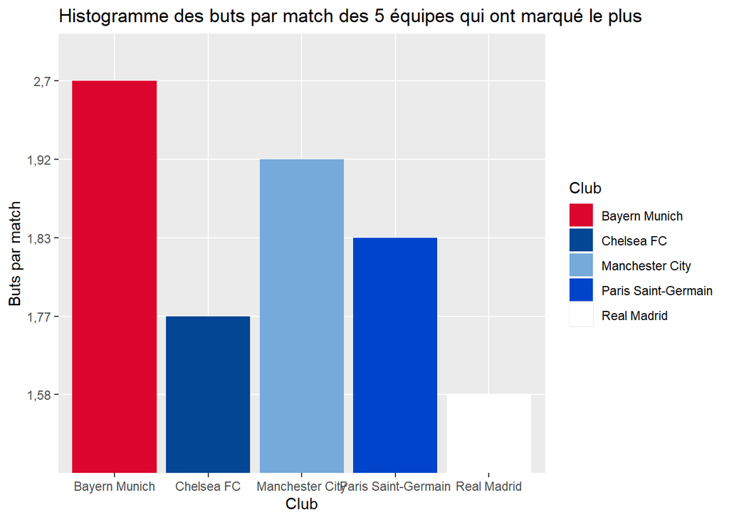

```r
# Liste de correspondance entre clubs et couleurs de maillot
colors <- list("Bayern Munich" = "#DC052D",
               "Manchester City" = "#75AADB",
               "Chelsea FC" = "#034694",
               "Paris Saint-Germain" = "#0044CC",
               "Real Madrid" = "#FFFFFF")

# Sélection des données
df_buteurs_top5 <- df_buteurs[[1]] |>
  filter(Rang <= 5) |>
  select(Club, `Buts/match`)|>
  arrange(`Buts/match`)


# Histogramme
ggplot(df_buteurs_top5, aes(x = Club, y = `Buts/match`, fill = Club)) +
  geom_bar(stat = "identity") +
  scale_fill_manual(values = colors) +
  labs(title = "Histogramme des buts par match des 5 équipes qui ont marqué le plus",
       x = "Club",
       y = "Buts par match")
```

## Meilleurs buteurs

```r
css_selector <- "#mw-content-text > div.mw-parser-output > table:nth-child(130) > tbody > tr > td:nth-child(1) > table > tbody"
df_buteurs <- data_html |> html_nodes(css_selector) |> html_table()
datatable(df_buteurs[[1]])
```

|  | Rang | Buteur | Club | Buts[22] | Passes | Minutes jouées |
| --- | --- | --- | --- | --- | --- | --- |
| 1 | 1 | Erling Braut Haaland | Borussia Dortmund | 10 | 2 | 705 |
| 2 | 2 | Kylian Mbappé | Paris SG | 8 | 3 | 900 |
| 3 | 3 | Neymar | Paris SG | 6 | 3 | 746 |
| 4 | 4 | Álvaro Morata | Juventus FC | 6 | 1 | 597 |
| 5 | 5 | Mohamed Salah | Liverpool FC | 6 | 1 | 781 |
| 6 | 6 | Olivier Giroud | Chelsea FC | 6 | 0 | 257 |
| 7 | 7 | Youssef En-Nesyri | FC Séville | 6 | 0 | 386 |
| 8 | 8 | Marcus Rashford | Manchester United | 6 | 0 | 416 |
| 9 | 9 | Karim Benzema | Real Madrid | 6 | 0 | 842 |
| 10 | 10 | Alassane Pléa | Borussia Mönchengladbach | 5 | 3 | 540 |

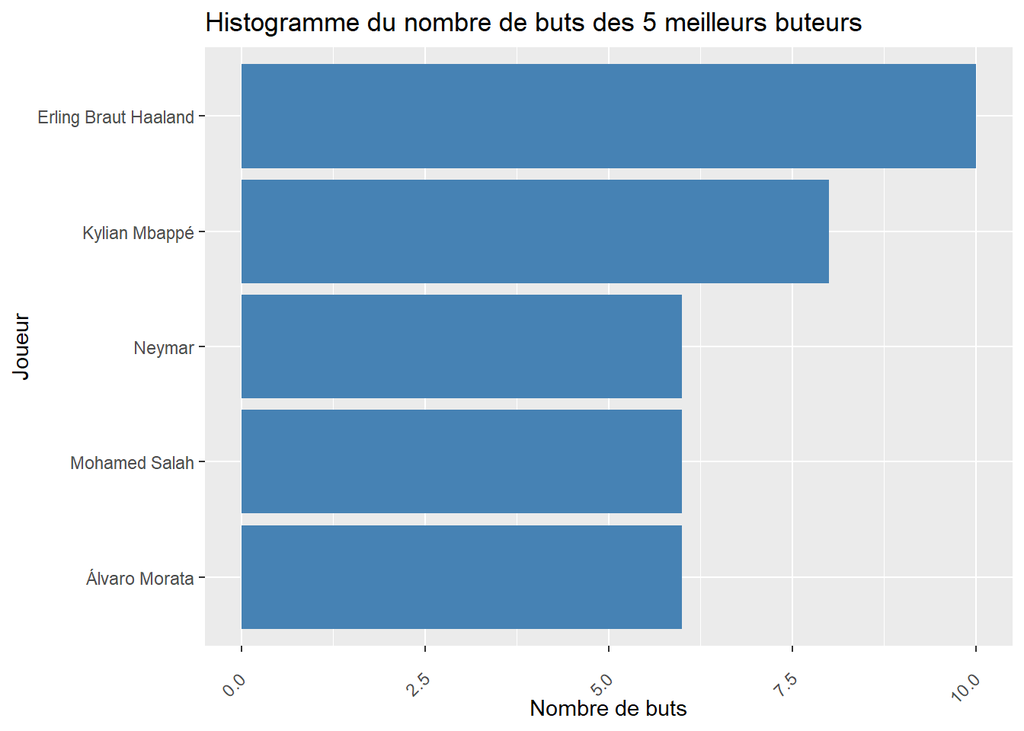

```r
df_buteurs_top5 <- df_buteurs[[1]] |>
  slice(1:5) |>
  arrange(desc(`Buts[22]`))

ggplot(df_buteurs_top5, aes(x = reorder(Buteur, `Buts[22]`), y = `Buts[22]`)) +
  geom_bar(stat = "identity", fill = "steelblue") +
  coord_flip() +
  theme(axis.text.x = element_text(angle = 45, vjust = 0.5, hjust=1)) +
  labs(title = "Histogramme du nombre de buts des 5 meilleurs buteurs",
       x = "Joueur",
       y = "Nombre de buts")
```

## Meilleurs passeurs

```r
css_selector <- "#mw-content-text > div.mw-parser-output > table:nth-child(130) > tbody > tr > td:nth-child(2) > table > tbody"
df_passeurs <- data_html |> html_nodes(css_selector) |> html_table()
datatable(df_passeurs[[1]])
```

|  | Rang | Passeur | Club | Passes[23] | Buts | Minutes jouées |
| --- | --- | --- | --- | --- | --- | --- |
| 1 | 1 | Juan Cuadrado | Juventus FC | 6 | 0 | 551 |
| 2 | 2 | Kevin De Bruyne | Manchester City | 4 | 3 | 609 |
| 3 | 3 | Joshua Kimmich | Bayern Munich | 4 | 1 | 617 |
| 4 | 4 | Ángel Di María | Paris SG | 4 | 1 | 697 |
| 5 | 5 | Kylian Mbappé | Paris SG | 3 | 8 | 900 |
| 6 | 6 | Neymar | Paris SG | 3 | 6 | 746 |
| 7 | 7 | Alassane Pléa | Borussia Mönchengladbach | 3 | 5 | 540 |
| 8 | 8 | Kingsley Coman | Bayern Munich | 3 | 3 | 459 |
| 9 | 9 | Angeliño | RB Leipzig | 3 | 3 | 627 |
| 10 | 10 | Phil Foden | Manchester City | 3 | 2 | 386 |

## Agregation

```r
passes_equipe <- df_passeurs[[1]] |> group_by(Club) |> summarize(nb_passes = sum(`Passes[23]`))
passes_equipe
```

```
## # A tibble: 6 x 2
##   Club                     nb_passes
##   <chr>                        <int>
## 1 Bayern Munich                    7
## 2 Borussia Mönchengladbach         3
## 3 Juventus FC                      6
## 4 Manchester City                  7
## 5 Paris SG                        10
## 6 RB Leipzig                       3
```